# Data Products Final Presentation

November 25, 2017

## Introduction

This project demonstrates a logistic regression model and compares it to a simple linear regression model.

The data used is the standard R airquality dataset. This datset contains measurements of ozone levels and relevant weather parameters. For this demonstration, I show the impact of air temperature on ozone.

## Model creation

Two models were created:

- A linear model \(y = \alpha + \beta x\), where \(\alpha\) and \(\beta\) are calculated from the data. For the airquality data, \(\alpha =\) -146.995491 and \(\beta =\) 2.4287033.
- A logistic model \(y = \frac{\alpha}{1 + e^{\beta - \gamma t}}\) where \(\alpha\), \(\beta\), and \(\gamma\) are calculated from the data. For the airquality data, \(\alpha =\) 117.7485675, \(\beta =\) 9.9131435, and \(\gamma =\) 0.1182928.

## Demonstration Program

The demonstration program can be found at https://dlkiskis.shinyapps.io/KiskisDataProductsFinal/

A graph of the data is shown on the right-side of the page. The lines representing the two models are shown.

You can interact with the page using the controls on the left side. You can choose the temperature. When you do that, the red and blue dots will move to show the predicted ozone level at that temperature, based on each model.

You can also choose individually whether you want the model lines to be displayed.

## Example Output

This is an example graph from the demonstration when the temperature is chosen to be 90 degrees.

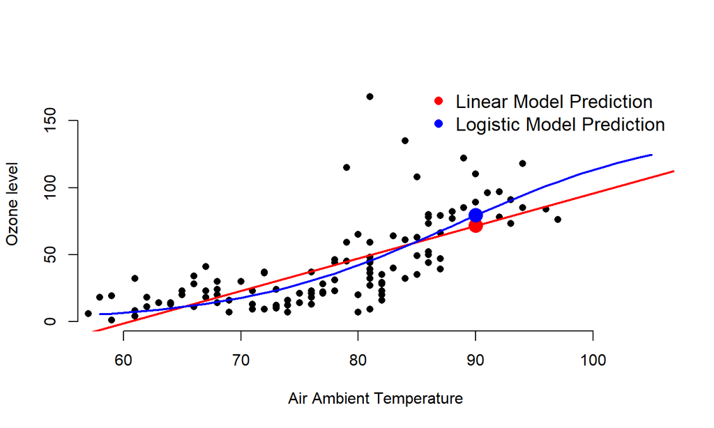